# Final Project Summary

Arundhati G., Zhongyang H., Adarsh K., Sumanth N.

2022-05-08

```r
library(foreign)
library(car)
```

```r
library(nnet)
library(ggplot2)
library(reshape2)
library(dplyr)
library(caret)
library(yardstick)
library(ggplot2)
```

# 1. Introduction

In recent years, California has seen record-breaking numbers of wildfires. The wildfires impact wildlife and residents and also have serious environmental implications. These outcomes result from heightened CO2 levels, temperatures, and precipitation. Previous exploratory analysis has shown that lower soil moisture and rainfall led to larger fires between 1992 to 2015, while lower soil moisture and rain led to more wildfires caused by equipment use. It was also found that higher rainfall resulted in a higher chance that a wildfire was caused by lightning. Government spending seemed to have a marginal impact on suppressing wildfires in California.

The first dataset we found detailed 24 years’ worth of nationwide wildfires from 1992 to 2015 along with their associated sizes, causes, time of occurrence, and other metadata. We felt that analyzing every state’s wildfire patterns would be an unfocused and unfruitful effort, so we decided to focus on California, as it deals with the most wildfires compared to other states in the United States.

However, we needed more data to conduct a more in-depth analysis, so we retrieved data from Cal-Adapt, which is an effort developed by the Geospatial Innovation Facility at the University of California, Berkeley focused on providing data that portrays climate change in California. From here, we were able to collect data about California’s daily air temperature, soil moisture, and rainfall. From there, we were able to combine it with our wildfire data by aggregating monthly averages. We also added California’s yearly budget to our combined dataset because we were curious as to how it played a factor in the volume and intensity of wildfires over the years.

# 2. Basic EDA of Wildfires in California

The initial exploratory data analysis made it clear that most fires in California were correlated with high average air temperatures, low soil moisture, and periods of low rainfall. To predict factors that may cause future wildfires, the following questions need to be addressed:

- How strong is the relationship between California fires and the average rainfall, air temperature, and soil moisture?
- Does California’s yearly fire suppression budget play any role in mitigating wildfires?
- How strongly can we predict large(class) wildfires using rainfall, air temperature, and soil moisture data?
- How can the long-term wildfires be predicted based on the month’s temperature, soil moisture, and rainfall with reasonable accuracy?

```r
library(dplyr)
data_wildfire=read.csv('final_wildfire.csv')
data_large=subset(data_wildfire, FIRE_SIZE_CLASS != 'A' & FIRE_SIZE_CLASS != 'B')
temp3=data_large %>% count(Year, DISCOVERY_DOY)
rainfall <- read.csv("rainfall_daily.csv")
soilmoisture <- read.csv("soilmoisture_daily.csv")
airtemp <- read.csv("airtemp_daily.csv")
airtemp$month <- strftime(airtemp$time, "%m")
airtemp$year <- strftime(airtemp$time, "%Y")
airtemp$DOY <- strftime(airtemp$time, "%j")
rainfall$year <- strftime(rainfall$time, "%Y")
rainfall$DOY <- strftime(airtemp$time, "%j")

cleaned_rainfall <- subset(rainfall, select = -c(time))
str(airtemp)
```

```
## 'data.frame':    23376 obs. of  5 variables:
##  $ time               : chr  "1950-01-01 00:00:00+00:00" "1950-01-02 00:00:00+00:00" "1950-01-03 00:00:00+00:00" "1950-01-04 00:00:00+00:00" ...
##  $ tair_day_livneh_vic: num  4.14 1.77 -3.09 -3.59 -2.75 ...
##  $ month              : chr  "01" "01" "01" "01" ...
##  $ year               : chr  "1950" "1950" "1950" "1950" ...
##  $ DOY                : chr  "001" "002" "003" "004" ...
```

```r
cleaned_airtemp <- subset(airtemp, select = -c(time))
soilmoisture$year <- strftime(rainfall$time, "%Y")
soilmoisture$DOY <- strftime(airtemp$time, "%j")

cleaned_soilmoisture <- subset(soilmoisture, select = -c(time))
joined1 <- merge(cleaned_airtemp, cleaned_soilmoisture, by.x=c("year",'DOY'), by.y=c("year",'DOY'))
joined2 <- merge(joined1, cleaned_rainfall, by.x=c("year",'DOY'), by.y=c("year",'DOY'))
joined2$year=as.integer(joined2$year)
joined2$DOY=as.integer(joined2$DOY)
```

```r
temp=aggregate(tair_day_livneh_vic~Year+month,data=data_wildfire,mean)
temp1=aggregate(soilmoist1_day_livneh_vic~Year+month,data=data_wildfire,mean)

temp2=aggregate(rainfall_day_livneh_vic~Year+month,data=data_wildfire,mean)

joined3=merge(temp,temp1,by.x=c('Year','month'),by.y=c('Year','month'))
joined3=merge(joined3,temp2,by.x=c('Year','month'),by.y=c('Year','month'))
temp1=data_wildfire %>% count(Year, month)

temp2=aggregate(FIRE_SIZE~Year+month,data=data_wildfire,mean)
joined4 = merge(temp2, temp1, by.x=c('Year', 'month'), by.y=c('Year', 'month'))
joined4 = merge(joined3, joined4, by.x=c('Year','month'), by.y=c('Year', 'month'))
```

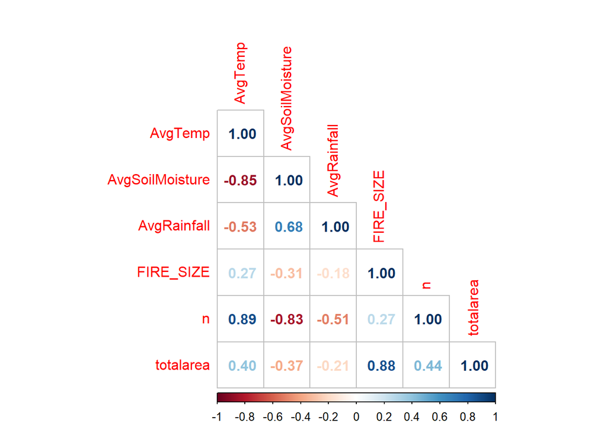

```r
library(corrplot)
joined4$totalarea=joined4$n*joined4$FIRE_SIZE
cordata=joined4
colnames(cordata)[3]='AvgTemp'
colnames(cordata)[4]='AvgSoilMoisture'
colnames(cordata)[5]='AvgRainfall'
cor_fire=cor(cordata[c(3,4,5,6,7,8)])
corrplot(cor_fire,method='number',type = 'lower', diag = TRUE)
```

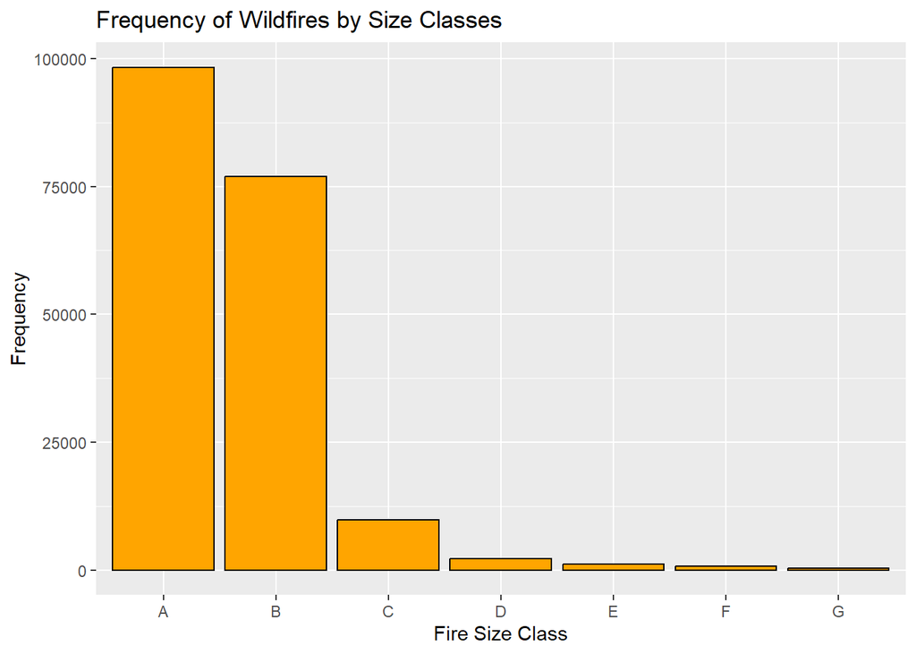

```r
ggplot(data = data_wildfire, aes(x = FIRE_SIZE_CLASS)) +
  geom_bar(col="black", fill="orange")+
  labs(x="Fire Size Class", y="Frequency", title="Frequency of Wildfires by Size Classes")
```

# 3. Linear Regression of Wildfires by cause (natural vs manmade)

First, linear modeling was used to predict the total number of fires in California, the fire size, and the burn area with respect to the environmental factors as the independent variables. These models were also looked at individually for naturally caused wildfires and those caused by people to see if there is a difference in the wildfire’s impact.

```r
summary_nature=read.csv('summary_nature.csv')
summary_peoplecaused=read.csv('summary_peoplecaused.csv')
```

```r
#Renaming variables in summary_nature
Avg_Temp <- summary_nature$tair_day_livneh_vic
Avg_SoilMoisture <- summary_nature$soilmoist1_day_livneh_vic
Avg_Rainfall <- summary_nature$rainfall_day_livneh_vic

#Renaming variables in summary_peoplecaused
Avg_Temp <- summary_peoplecaused$tair_day_livneh_vic
Avg_SoilMoisture <- summary_peoplecaused$soilmoist1_day_livneh_vic
Avg_Rainfall <- summary_peoplecaused$rainfall_day_livneh_vic
```

## 3.1 Model for all fire incidents

```r
model_nnature <- lm(log(n)~ Avg_Temp + Avg_SoilMoisture, data = summary_nature)
#summary(model_nnature)
xkabledply(model_nnature, title = paste("Nature Caused:",format(formula(model_nnature)) ))
```

Nature Caused: log(n) ~ Avg_Temp + Avg_SoilMoisture

|  | Estimate | Std. Error | t value | Pr(>\|t\|) |
| --- | --- | --- | --- | --- |
| (Intercept) | 8.1533 | 0.3724 | 21.89 | 0 |
| Avg_Temp | 0.0595 | 0.0090 | 6.59 | 0 |
| Avg_SoilMoisture | -0.2529 | 0.0167 | -15.14 | 0 |

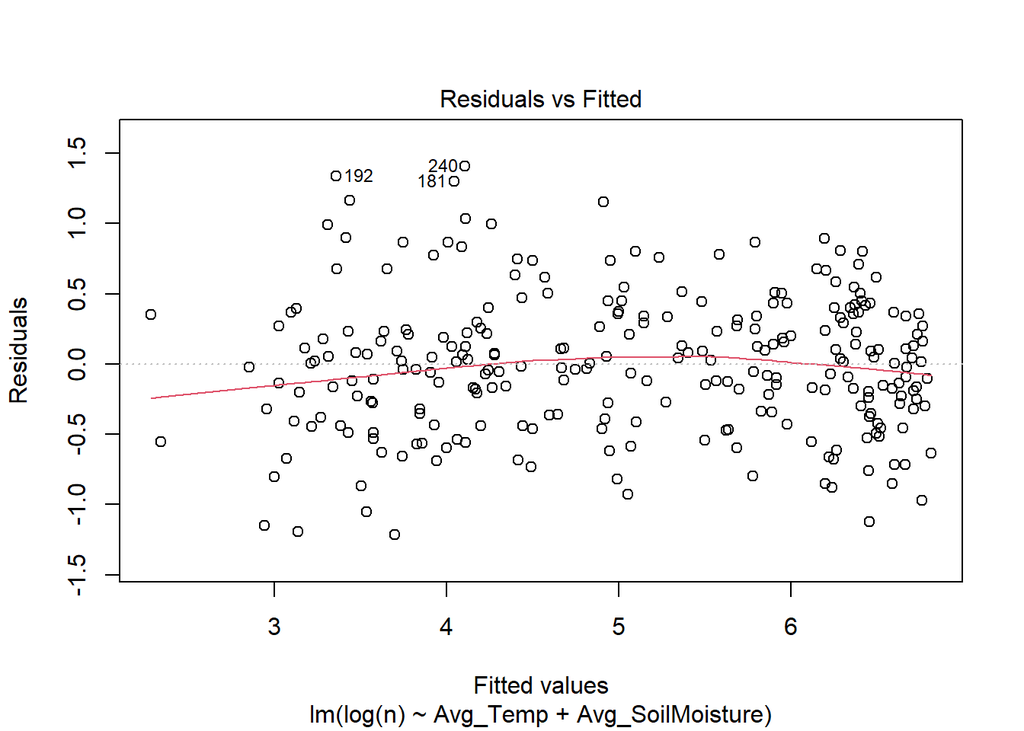

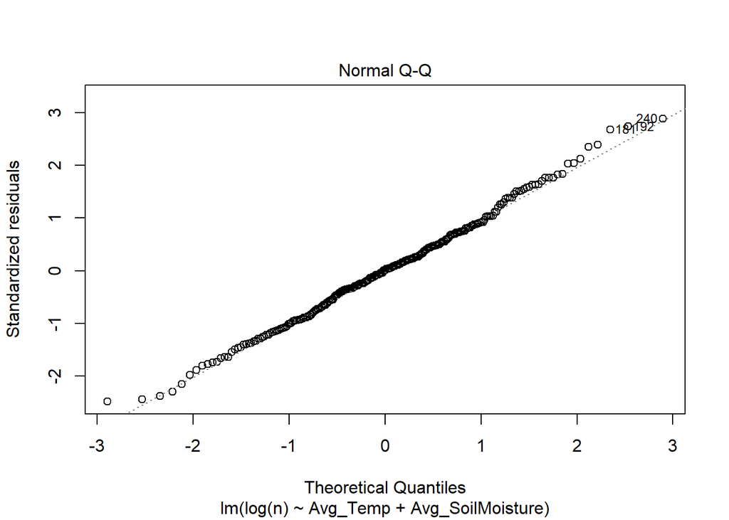

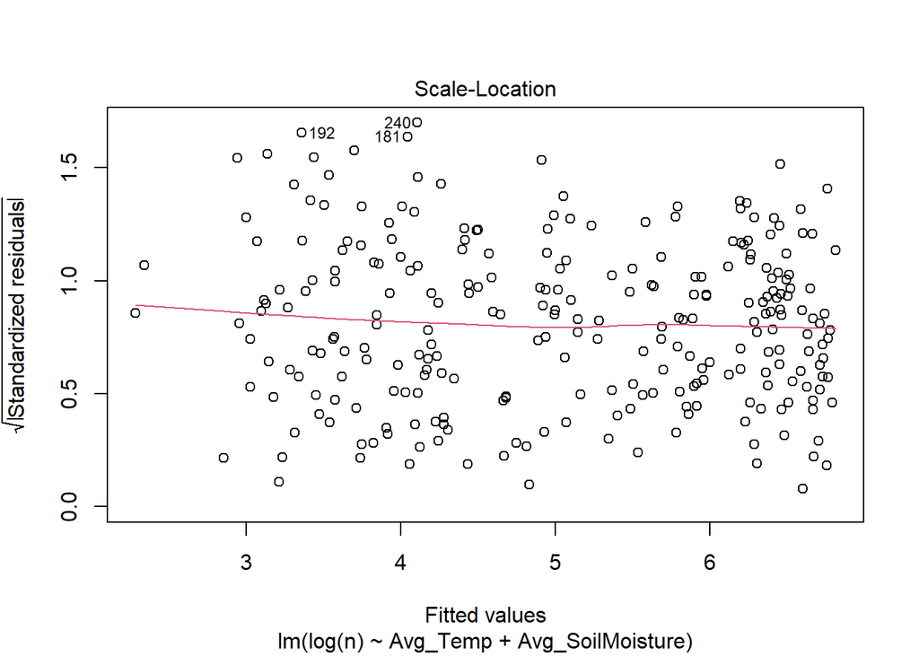

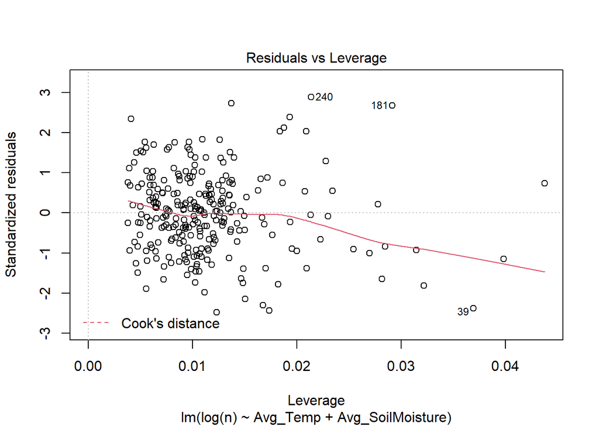

```r
plot(model_nnature)
```

```r
## Logn ~ nature variables        - PEOPLE CAUSED (P)
model_npeople <- lm(log(n)~ Avg_Temp + Avg_SoilMoisture, data = summary_peoplecaused)
#summary(model_npeople)
xkabledply(model_npeople, title = paste("People Caused:",format(formula(model_npeople)) ))
```

People Caused: log(n) ~ Avg_Temp + Avg_SoilMoisture

|  | Estimate | Std. Error | t value | Pr(>\|t\|) |
| --- | --- | --- | --- | --- |
| (Intercept) | 7.2814 | 0.3131 | 23.26 | 0 |
| Avg_Temp | 0.0526 | 0.0076 | 6.93 | 0 |
| Avg_SoilMoisture | -0.2251 | 0.0140 | -16.03 | 0 |

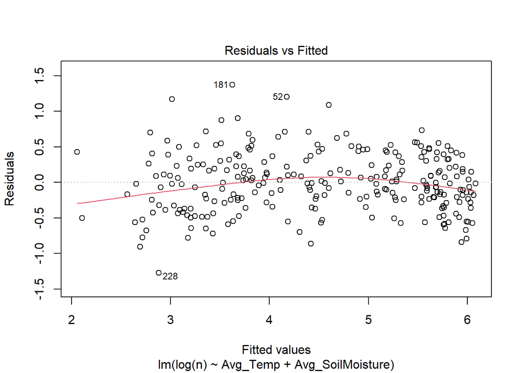

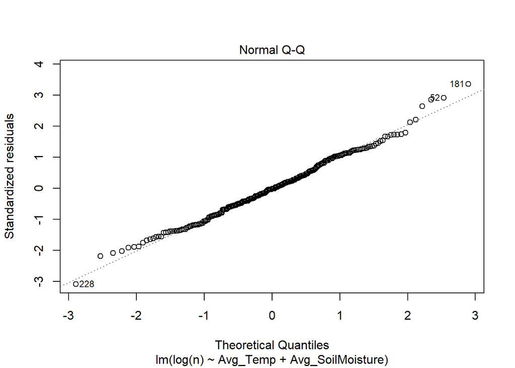

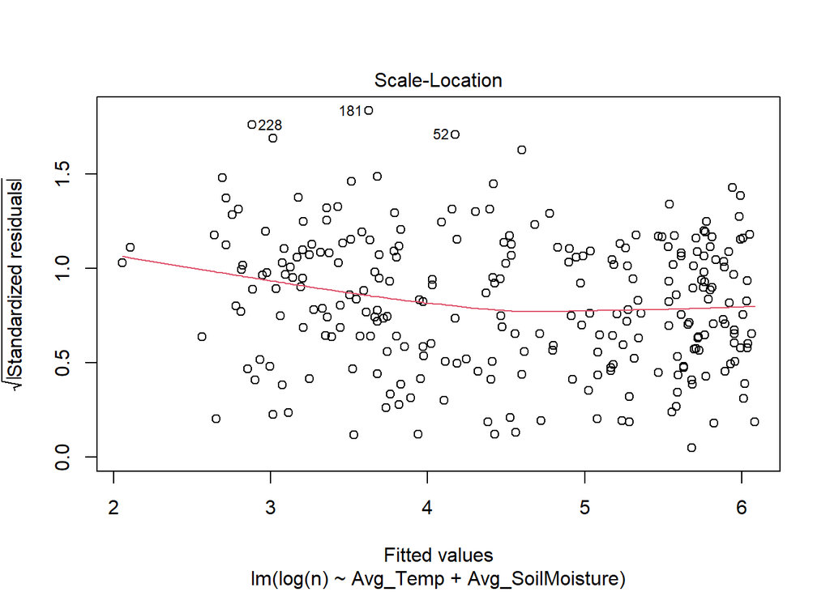

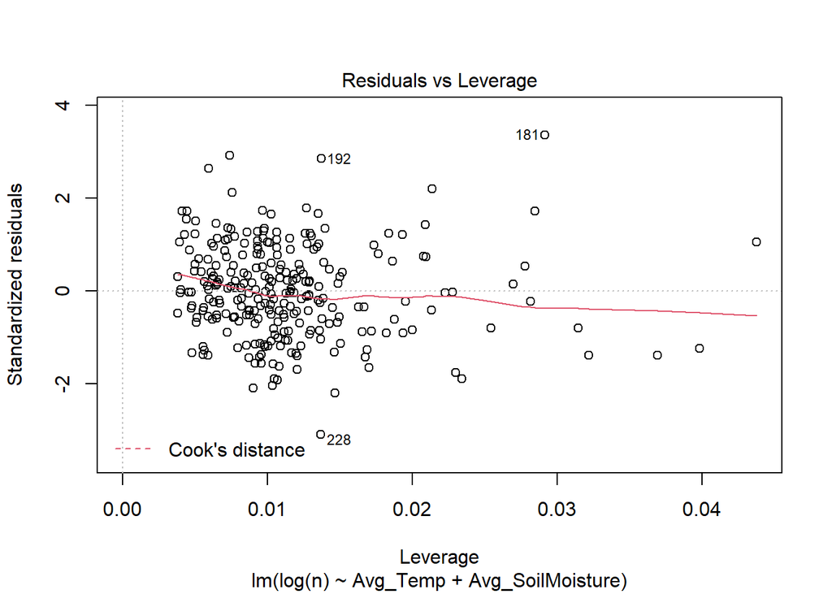

```r
plot(model_npeople)
```

## 3.2 Model for fire size

```r
## FIRE_SIZE ~ nature variables       - NATURE CAUSED (N)
model_sizenature <- lm(log(FIRE_SIZE) ~ Avg_Temp + Avg_SoilMoisture , data = summary_nature)
#summary(model_sizenature)
xkabledply(model_sizenature, title = paste("Nature Caused:",format(formula(model_sizenature)) ))
```

Nature Caused: log(FIRE_SIZE) ~ Avg_Temp + Avg_SoilMoisture

|  | Estimate | Std. Error | t value | Pr(>\|t\|) |
| --- | --- | --- | --- | --- |
| (Intercept) | 7.5705 | 1.0788 | 7.02 | 0.000 |
| Avg_Temp | 0.0291 | 0.0261 | 1.11 | 0.266 |
| Avg_SoilMoisture | -0.3783 | 0.0484 | -7.82 | 0.000 |

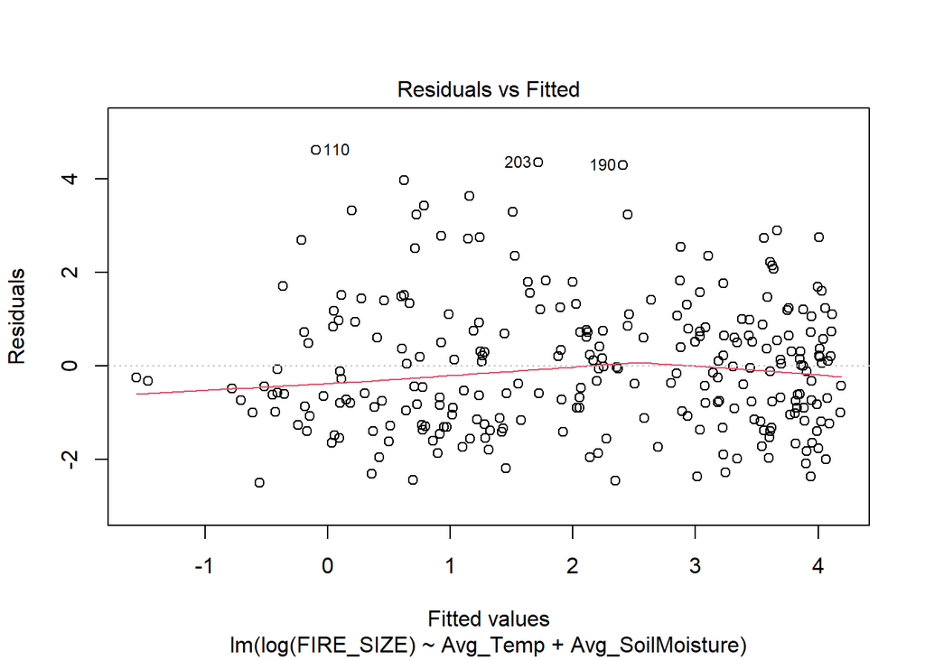

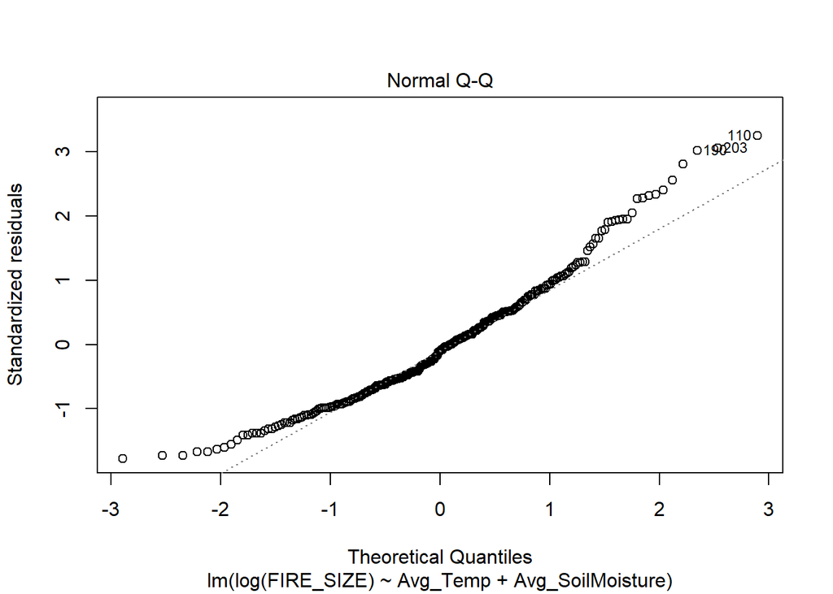

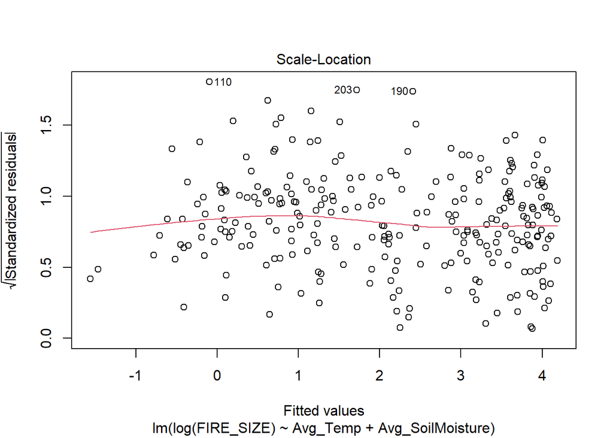

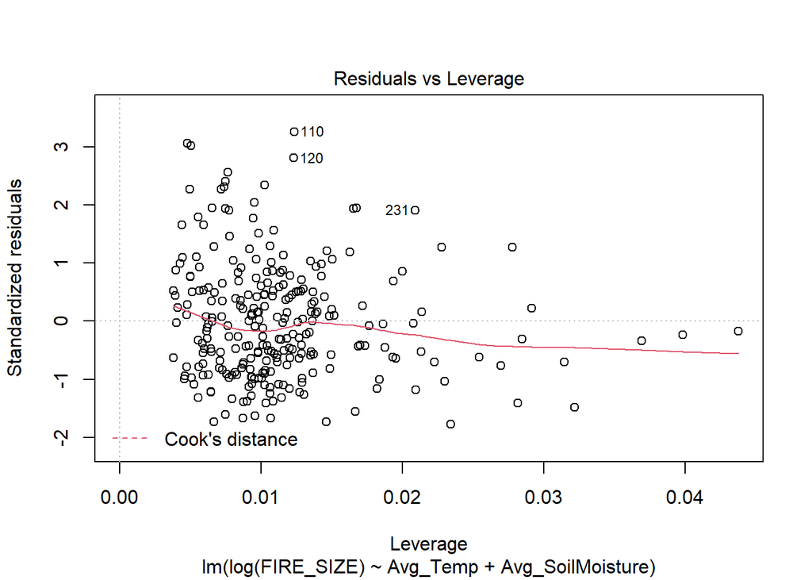

```r
plot(model_sizenature)
```

```r
model_sizepeople <- lm(log(FIRE_SIZE) ~ Avg_Temp + Avg_SoilMoisture , data = summary_peoplecaused)
#summary(model_sizepeople)
xkabledply(model_sizepeople, title = paste("People Caused:",format(formula(model_sizepeople) )))
```

People Caused: log(FIRE_SIZE) ~ Avg_Temp + Avg_SoilMoisture

|  | Estimate | Std. Error | t value | Pr(>\|t\|) |
| --- | --- | --- | --- | --- |
| (Intercept) | 4.8934 | 1.1114 | 4.40 | 0.0000 |
| Avg_Temp | 0.0756 | 0.0269 | 2.80 | 0.0054 |
| Avg_SoilMoisture | -0.2687 | 0.0499 | -5.39 | 0.0000 |

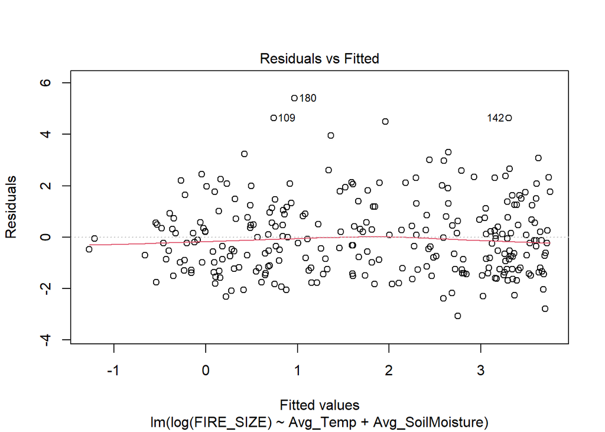

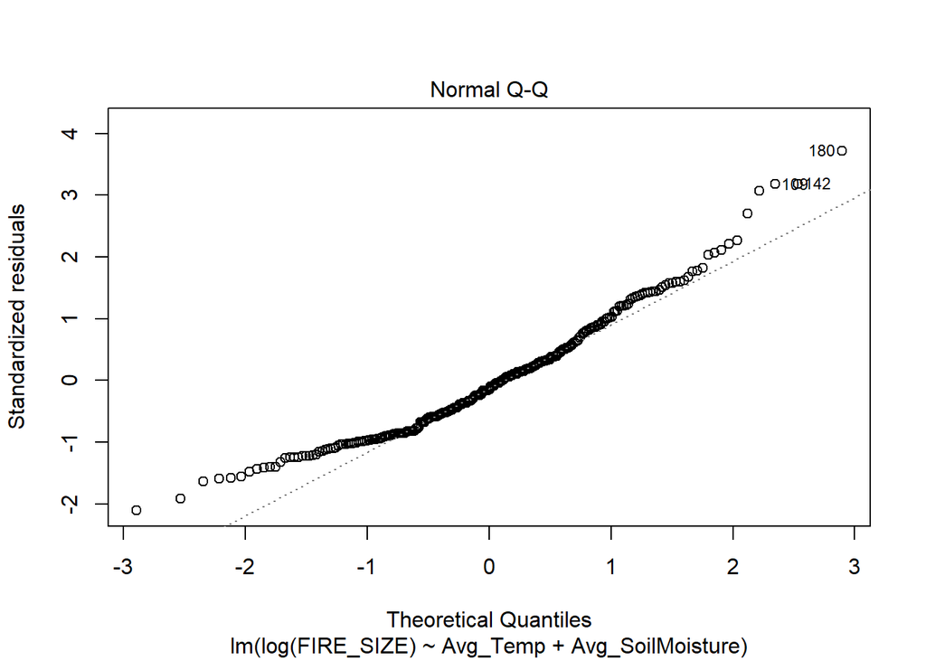

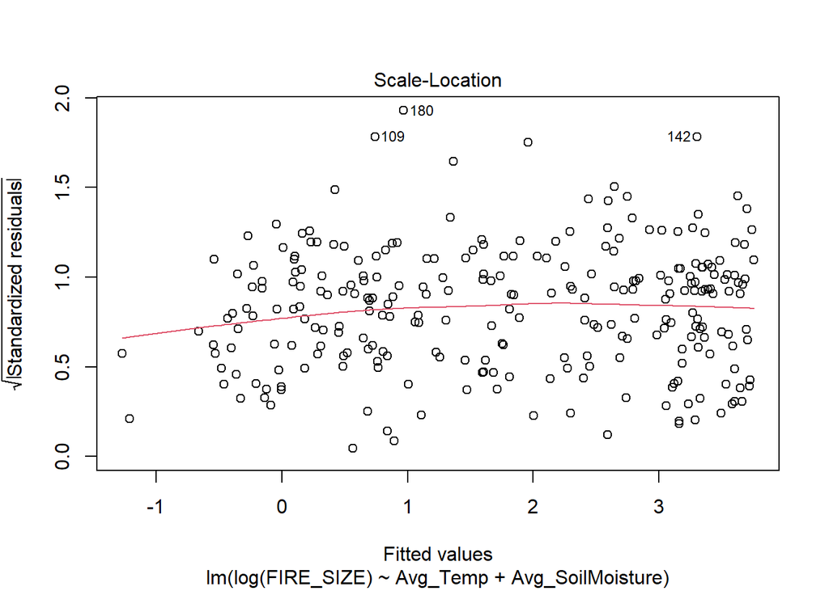

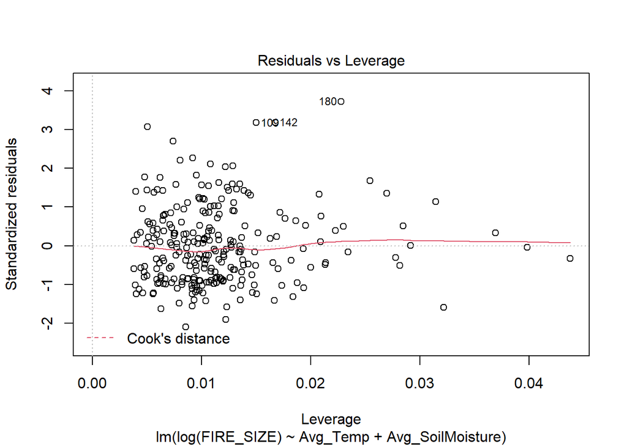

```r
plot(model_sizepeople)
```

Next, we modeled the environmental factors and their impact on the fire size. The environmental factors can explain 52.2% of the variation in the fire size in the naturally caused fires model, whereas only 46.15% of the variation could be explained by those factors in the people caused fires model. The relationship of the independent variables was the same with the fire size as it was with the number of fires.

## 3.3 Model for burn area

```r
model_areanature <- lm(log(FIRE_SIZE*n) ~ Avg_Temp + Avg_SoilMoisture , data = summary_nature)
#summary(model_areanature)
xkabledply(model_areanature, title = paste("Nature Caused:",format(formula(model_areanature)) ))
```

Nature Caused: log(FIRE_SIZE * n) ~ Avg_Temp + Avg_SoilMoisture

|  | Estimate | Std. Error | t value | Pr(>\|t\|) |
| --- | --- | --- | --- | --- |
| (Intercept) | 15.7238 | 1.1627 | 13.52 | 0.0000 |
| Avg_Temp | 0.0887 | 0.0282 | 3.15 | 0.0018 |
| Avg_SoilMoisture | -0.6312 | 0.0522 | -12.10 | 0.0000 |

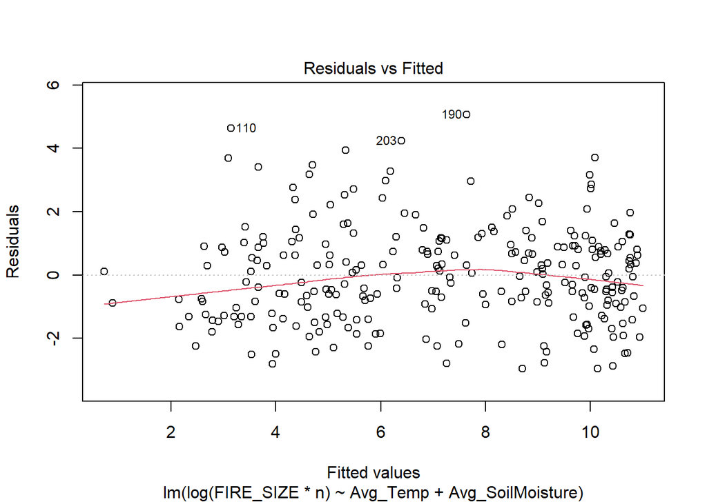

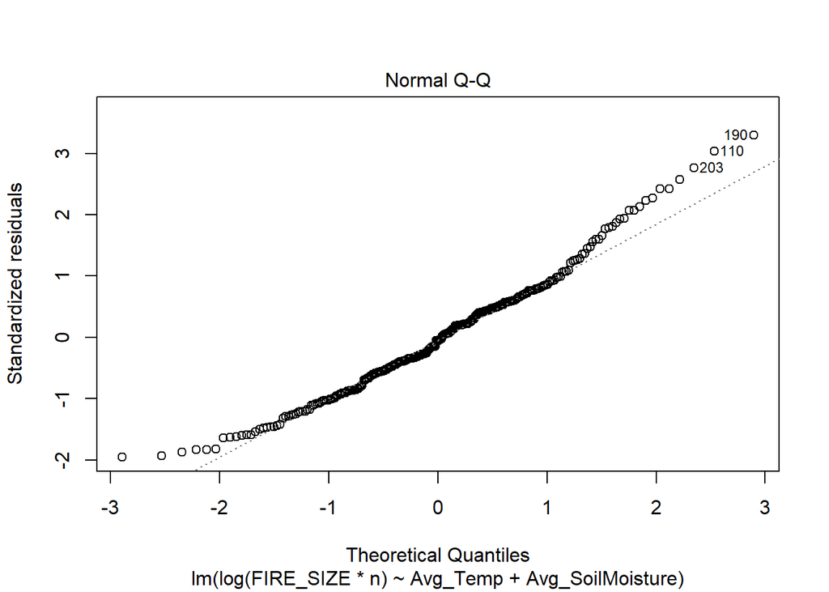

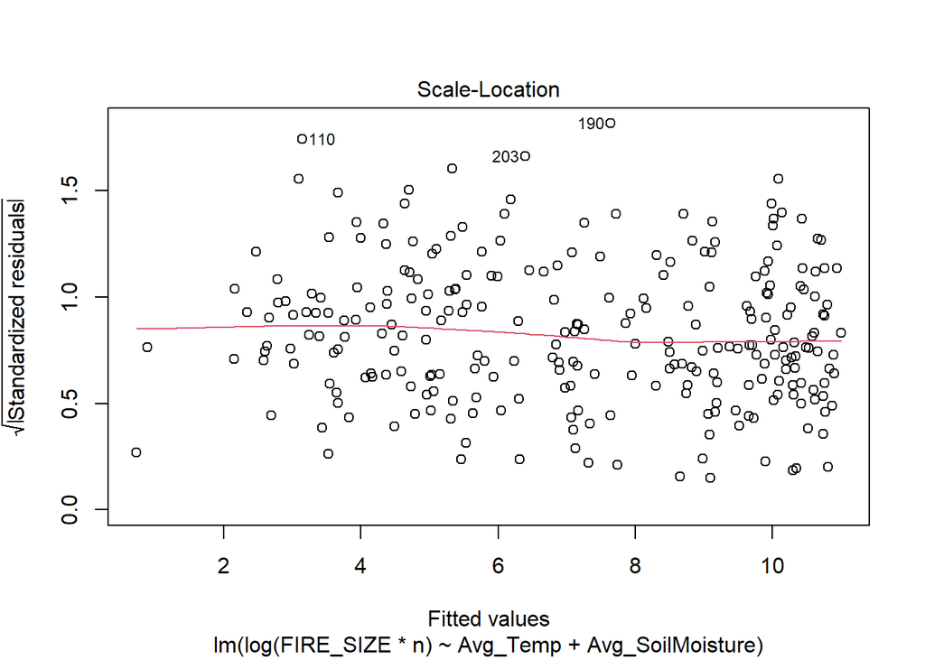

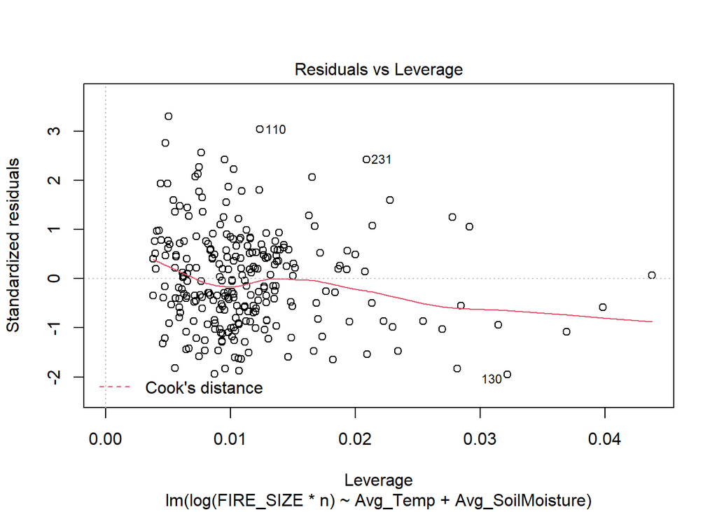

```r
plot(model_areanature)
```

```r
model_areapeople <- lm(log(FIRE_SIZE*n) ~ Avg_Temp + Avg_SoilMoisture , data = summary_peoplecaused)
#summary(model_areapeople)
xkabledply(model_areapeople, title = paste("People Caused:",format(formula(model_areapeople) )))
```

People Caused: log(FIRE_SIZE * n) ~ Avg_Temp + Avg_SoilMoisture

|  | Estimate | Std. Error | t value | Pr(>\|t\|) |
| --- | --- | --- | --- | --- |
| (Intercept) | 12.175 | 1.2004 | 10.14 | 0 |
| Avg_Temp | 0.128 | 0.0291 | 4.40 | 0 |
| Avg_SoilMoisture | -0.494 | 0.0538 | -9.17 | 0 |